# Protein Binding Models

Jonathan Davies

2021-03-28

When collecting protein-ligand binding data using a technique such as Biolayer Interferometry (BLI) or Surface Plasmon Resonance (SPR), it is useful to simulate binding curves to help optimise your experiments. After initial binding parameters are known, binding curves can be simulated and parameters such as: analyte concentration, time of association, dissociation etc. can be varied. The models within this package may also be used to fit a curve to measured binding data using a non-linear regression.

Currently, two binding models are included with this package:

- 1:1 binding
- 2:1 heterogeneous binding.

## 1:1 Binding

Usage: `binding1to1(t, t0, conc, kon, koff, rmax)`

$$Response = \frac{[A]R_{max}}{[A] + K_{D}}(1 - e^{-(K_{on}[A] + K_{off})t})$$

Parameters:

- $t$, time (s) - can also be a vector.
- $t_0$, time of dissociation.
- $conc$, concentration of analyte in M.
- $k_{on}$ $(k_a)$, units $M^{-1}s^{-1}$
- $k_{off}$ $(k_d)$, units $s^{-1}$
- $R_{max}$, maxiumum response.

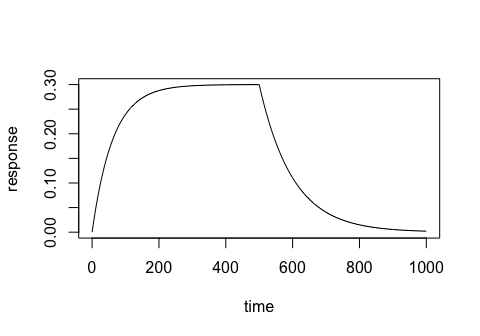

Example of a 1:1 binding curve.

```r
library(pbm)
time <- seq(0, 1000)
response <- binding1to1(time, 500, 6e-7, 10000, 0.01, 0.8)
plot(time, response, type = "l")
```

### Optional drift parameter

```r
library(pbm)
time <- seq(0, 1000)
response <- binding1to1(time, 500, 6e-7, 10000, 0.01, 0.8, drift = 1e-04)
```

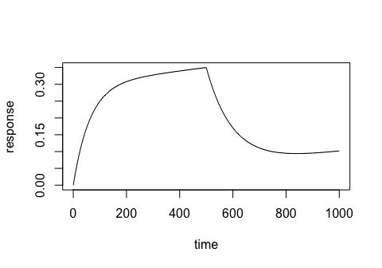

Example of a 1:1 binding curve with baseline drift.

```r
plot(time, response, type = "l")
```

## 2:1 Binding

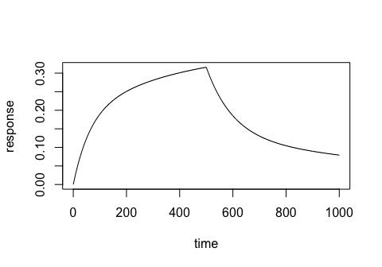

Example of a 2:1 binding curve.

```r
library(pbm)
time <- seq(0, 1000)
response <- binding2to1(time, 500, 6e-7, 10000, 0.01, 0.5, 2500, 0.001, 0.3)
plot(time, response, type = "l")
```

## Non-linear Regression

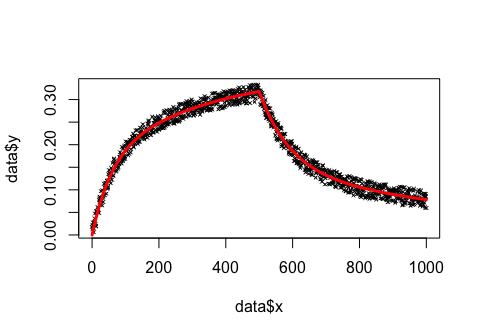

Example of 2:1 heterogeneous model fit.

```r
library(pbm)

# Generate example binding data with noise
time <- seq(0, 1000)
response <- binding2to1(time, 500, 6e-7, 10000, 0.01, 0.5, 2500, 0.001, 0.3)
noisyresponse <- jitter(response, amount = 0.02)
data <- data.frame(time, noisyresponse)
names(data) <- c("x", "y")

# Fit a nlm to binding data
startingvalues <- list(kon1 = 70000, koff1 = 0.01, rmax1 = 0.3, kon2 = 9000, koff2 = 0.004, rmax2 = 0.3)
fit <- nls(y ~ binding2to1(x, 500, 6e-7, kon1, koff1, rmax1, kon2, koff2, rmax2),
  data = data,
  start = startingvalues)

# Plot the fitted model
plot(data$x, data$y, type = "p", pch = 4, cex = 0.5)
par(col = "red", lwd = 3)
lines(data$x, predict(fit, list(x = data$x)))
```

Parameters predicted from fitted model:

| kon1 | koff1 | rmax1 | kon2 | koff2 | rmax2 |
| --- | --- | --- | --- | --- | --- |
| 10163.93 | 0.0108452 | 0.4813816 | 2262.95 | 0.0012512 | 0.3817 |

## Estimating ideal association times

When collecting data, it is recommended to allow the associtaion to reach equilibrium. The command `tteq()`, by default, returns the time taken to reach 95% equilibrium. See below for an example usage.

```r
# Choose a range of analyte concentrations and give known parameters.
conc_range <- c(6e-7, 3e-7, 1.75e-7, 8.75e-8, 2.916e-8)
kon  <- 10000
koff <- 0.01

# Calculate the time to equilibrium for each concentration.
tteq(conc_range, kon, koff)
```

```
#> [1] 187.2333 230.4409 254.9559 275.4696 291.0852
```

Now we can see that our time to equilibrium for the given concentrations ranges from 187 seconds to 291 seconds. Given these values we can see the difference using calculated data. Below are curves for the given parameters with two different association times.

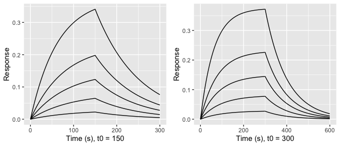

Selecting an appropriate association time.

```r
library(ggplot2)
library(gridExtra)

t <- seq(0, 300)
t0 <-  median(t)
plot1 <- ggplot()
for (conc in conc_range) {
  curve <- binding1to1(t, t0, conc, 10000, 0.01, 1)
  plot1 <- plot1 + geom_line(aes_string(x = t, y = curve))
}

t <- seq(0, 600)
t0 <-  median(t)
plot2 <- ggplot()
for (conc in conc_range) {
  curve <- binding1to1(t, t0, conc, 10000, 0.01, 1)
  plot2 <- plot2 + geom_line(aes_string(x = t, y = curve))
}

plot1 <- plot1+labs(x = "Time (s), t0 = 150")
plot1 <- plot1+labs(y = "Response")
plot2 <- plot2+labs(x = "Time (s), t0 = 300")
plot2 <- plot2+labs(y = "Response")

grid.arrange(plot1, plot2, ncol = 2)
```